# Statistical inference course project

## R Markdown

Part 1: Simulation Exercise Instructions :

In this project you will investigate the exponential distribution in R and compare it with the Central Limit Theorem. The exponential distribution can be simulated in R with rexp(n, lambda) where lambda is the rate parameter. Set lambda = 0.2 for all of the simulations. You will investigate the distribution of averages of 40 exponentials. Note that you will need to do a thousand simulations.

Simulating the exponential distribution :

```r
set.seed(16)
lambda <-0.2
n <- 40
sim <- 1000
#We create 1K times a sample of 40 exponentials, then compute its mean
exp_dis_sample <- replicate (sim, mean(rexp (n,lambda)))
```

Calculating the sample mean :

```r
mean(exp_dis_sample)
```

```
## [1] 4.994828
```

Calculating the theoretical mean :

```r
1/lambda
```

```
## [1] 5
```

```r
##There is a very small difference between the theoretical and sample means of this exponential dsitribution
abs(mean(exp_dis_sample)-1/lambda)
```

```
## [1] 0.005172086
```

Calculating the sample variance :

```r
var(exp_dis_sample)
```

```
## [1] 0.6132857
```

Calculating the theoretical variance for a population of n:

```r
(1/lambda)^2/n
```

```
## [1] 0.625
```

```r
##There is a very small difference between the theoretical and sample variances of this exponential dsitribution
abs(var(exp_dis_sample)-(1/lambda)^2/n)
```

```
## [1] 0.01171433
```

Plotting the distribution, and comparing it to a normal distribution of similar mean and standard deviation :

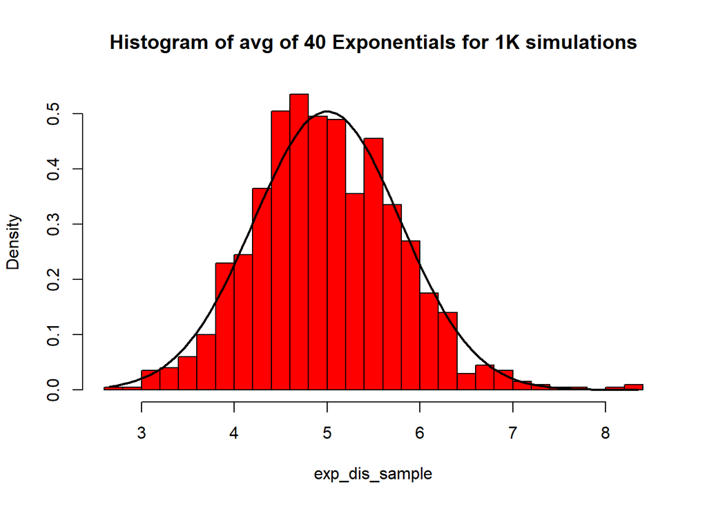

Part 2: Basic Inferential Data Analysis Instructions :

Now in the second portion of the project, we’re going to analyze the ToothGrowth data in the R datasets package.

```r
library(datasets)
df<-data(ToothGrowth)
#First rows of the data sets
head(ToothGrowth)
```

```
##    len supp dose
## 1  4.2   VC  0.5
## 2 11.5   VC  0.5
## 3  7.3   VC  0.5
## 4  5.8   VC  0.5
## 5  6.4   VC  0.5
## 6 10.0   VC  0.5
```

```r
#length of the dataset
dim(ToothGrowth)
```

```
## [1] 60  3
```

```r
#Some statistics summaries of the dataset's columns
summary(ToothGrowth)
```

```
##       len        supp         dose
##  Min.   : 4.20   OJ:30   Min.   :0.500
##  1st Qu.:13.07   VC:30   1st Qu.:0.500
##  Median :19.25           Median :1.000
##  Mean   :18.81           Mean   :1.167
##  3rd Qu.:25.27           3rd Qu.:2.000
##  Max.   :33.90           Max.   :2.000
```

```r
# Display different summary
str(ToothGrowth)
```

```
## 'data.frame':    60 obs. of  3 variables:
##  $ len : num  4.2 11.5 7.3 5.8 6.4 10 11.2 11.2 5.2 7 ...
##  $ supp: Factor w/ 2 levels "OJ","VC": 2 2 2 2 2 2 2 2 2 2 ...
##  $ dose: num  0.5 0.5 0.5 0.5 0.5 0.5 0.5 0.5 0.5 0.5 ...
```

```r
#Only 3 values for dose
unique(ToothGrowth$dose)
```

```
## [1] 0.5 1.0 2.0
```

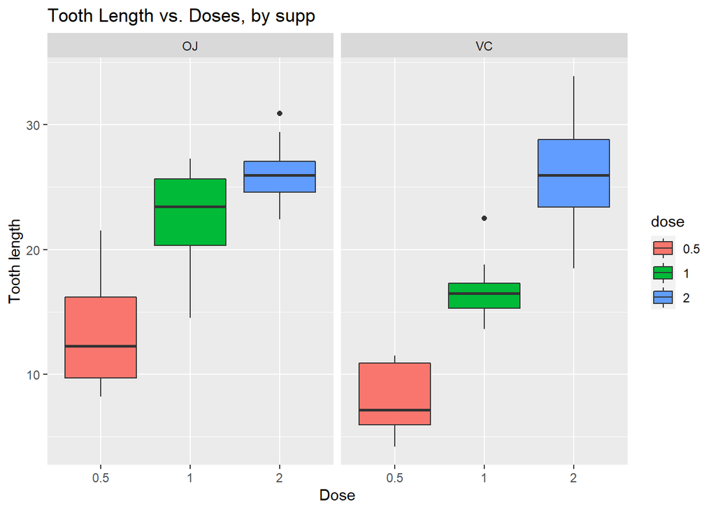

```r
#Some plots to better understand the data :
#Transform dose into factors
ToothGrowth$dose<-as.factor(ToothGrowth$dose)
#contruct a boxplot
library(ggplot2)
ggplot(data = ToothGrowth, aes(x = dose, y = len)) +
  geom_boxplot(aes(fill = dose), width = 0.8) + xlab('Dose') + ylab('Tooth length') + facet_grid(~supp) +ggtitle('Tooth Length vs. Doses, by supp')
```

Calculating confidence intervals :

Hypothesis1 : The supplements offer the same tooth growth

```r
# Run a t-test on the data
t.test(len~supp,data=ToothGrowth)
```

```
##
##  Welch Two Sample t-test
##
## data:  len by supp
## t = 1.9153, df = 55.309, p-value = 0.06063
## alternative hypothesis: true difference in means is not equal to 0
## 95 percent confidence interval:
##  -0.1710156  7.5710156
## sample estimates:
## mean in group OJ mean in group VC
##         20.66333         16.96333
```

the p-value is 6%, so higher than 5%, and the confidence interval contains 0. The null hypothesis cannot be rejected.

Hypothesis2 : The supplements offer the same tooth growth For the dosage of ‘0.5mg/day’

```r
# Run a t-test on the data for dose .5mg/day
df<-subset(ToothGrowth,dose==.5)
t.test(len~supp,data=df)
```

```
##
##  Welch Two Sample t-test
##
## data:  len by supp
## t = 3.1697, df = 14.969, p-value = 0.006359
## alternative hypothesis: true difference in means is not equal to 0
## 95 percent confidence interval:
##  1.719057 8.780943
## sample estimates:
## mean in group OJ mean in group VC
##            13.23             7.98
```

the p-value is .6%, so less than 5%, and the confidence interval is higher than 0. So the results are statistically significant and the null hypothesis is rejected. The OJ supp offer more tooth growth than VC.

```r
# Run a t-test on the data for dose 1mg/day
df<-subset(ToothGrowth,dose==1)
t.test(len~supp,data=df)
```

```
##
##  Welch Two Sample t-test
##
## data:  len by supp
## t = 4.0328, df = 15.358, p-value = 0.001038
## alternative hypothesis: true difference in means is not equal to 0
## 95 percent confidence interval:
##  2.802148 9.057852
## sample estimates:
## mean in group OJ mean in group VC
##            22.70            16.77
```

the same is true for a dosage of 1mg/day

```r
# Run a t-test on the data for dose 2mg/day
df<-subset(ToothGrowth,dose==2)
t.test(len~supp,data=df)
```

```
##
##  Welch Two Sample t-test
##
## data:  len by supp
## t = -0.046136, df = 14.04, p-value = 0.9639
## alternative hypothesis: true difference in means is not equal to 0
## 95 percent confidence interval:
##  -3.79807  3.63807
## sample estimates:
## mean in group OJ mean in group VC
##            26.06            26.14
```

Unfortunately for a dosage of 2mg/day, the p-value is very high, and the confidence interval contains 0. So the null hypothesis cannot be rejected.

Conclusion : * For the dosages of .5 and 1mg/day, the OJ supplement offers more tooth growth than VC. However, we failed to reject the null hypothesis for the dosage 2mg/day and conclude there is no significant difference between both supplements.